# Midterm2

Rabin Paudel

11/15/2021

### Problem 1 (30 pts)

#### You can extract the raw data for this table as follows.

```r
library("stringr")
library("tidyverse")
```

```r
#install.packages("dplyr")
library(dplyr)
library(ggplot2)
library("pdftools") ## install.library("pdftools") if this library is missing
temp_file <- tempfile()
url <- paste0("https://www.pnas.org/content/suppl/2015/09/16/",
"1510159112.DCSupplemental/pnas.201510159SI.pdf")
download.file(url, temp_file)
txt <- pdf_text(temp_file)
file.remove(temp_file)
```

```
## [1] TRUE
```

```r
## [1] TRUE
raw_data <- txt[2]
raw_data
```

```
## [1] "                       Table S1. Numbers of applications and awarded grants, along with success rates for male and\n                       female applicants, by scientific discipline\n                                                       Applications, n                    Awards, n         …
```

#### First, use the function str_split from the stringr library to split the

#### raw_data string into lines. For example.

```r
raw_data_lines <- stringr::str_split(raw_data, "\n")[[1]]
head(raw_data_lines, 8)
```

```
## [1] "                       Table S1. Numbers of applications and awarded grants, along with success rates for male and"
## [2] "                       female applicants, by scientific discipline"
## [3] "                                                       Applications, n                    Awards, n                  Success rates, %"
## [4] ""
## [5] "                       Discipline              Total       Men      Women       Total      Men     Women        Total     Men       Women"
## [6] ""
## [7] "                       Total                   2,823      1,635      1,188       467       290        177       16.5      17.7a      14.9b"
## [8] "                       Chemical sciences         122         83         39        32        22         10       26.2      26.5a      25.6a"
```

#### The numbers in the tables are recorded in the 7th through 15th

#### lines/elements of raw_data_lines.

```r
tab_data <- raw_data_lines[7:15]
tab_data
```

```
## [1] "                       Total                   2,823      1,635      1,188       467       290        177       16.5      17.7a      14.9b"
## [2] "                       Chemical sciences         122         83         39        32        22         10       26.2      26.5a      25.6a"
## [3] "                       Physical sciences         174        135         39        35        26          9       20.1      19.3a      23.1a"
## [4] "                       Physics                    76         67          9        20        18          2       26.3      26.9a      22.2a"
## [5] "                       Humanities                396        230        166        65        33         32       16.4      14.3a      19.3a"
## [6] "                       Technical sciences        251        189         62        43        30         13       17.1      15.9a      21.0a"
## [7] "                       Interdisciplinary         183        105         78        29        12         17       15.8      11.4a      21.8a"
## [8] "                       Earth/life sciences       282        156        126        56        38         18       19.9      24.4a      14.3b"
## [9] "                       Social sciences           834        425        409       112        65         47       13.4      15.3a      11.5a"
```

#### We can now try to use str_trim and str_split to split each line into

#### separate columns. We might want to take a careful look at the arguments

#### of str_split or try out the examples provided in the help page for

#### str_split.Then,After doing the above steps, you should now have something

#### resembling what we want. Now add the column names and remember to convert

#### the values in most of the columns into numbers. The function across in

#### dplyr might be useful here.

#### As always, refer to do this cheatsheet.

### This is the required table.

```r
tab_data1 <- str_trim(tab_data, side = c("both"))
tab_data2 <- str_split(tab_data1, "\\s{2,}", simplify = TRUE) %>%
  data.frame() %>%
  setNames(c('discipline', 'app_T', 'app_M', 'app_F', 'awards_T', 'awards_M',
             'awards_F', 'success_rates_T', 'success_rates_M',
             'success_rates_F')) %>% mutate_at(-1, parse_number) %>%
  as_tibble()
tab_data2
```

```
## # A tibble: 9 × 10
##   discipline        app_T app_M app_F awards_T awards_M awards_F success_rates_T
##   <chr>             <dbl> <dbl> <dbl>    <dbl>    <dbl>    <dbl>           <dbl>
## 1 Total              2823  1635  1188      467      290      177            16.5
## 2 Chemical sciences   122    83    39       32       22       10            26.2
## 3 Physical sciences   174   135    39       35       26        9            20.1
## 4 Physics              76    67     9       20       18        2            26.3
## 5 Humanities          396   230   166       65       33       32            16.4
## 6 Technical scienc…   251   189    62       43       30       13            17.1
## 7 Interdisciplinary   183   105    78       29       12       17            15.8
## 8 Earth/life scien…   282   156   126       56       38       18            19.9
## 9 Social sciences     834   425   409      112       65       47            13.4
## # … with 2 more variables: success_rates_M <dbl>, success_rates_F <dbl>
```

### Problem 2 (30pts)

#### The data had been studied in this article and is included as part the

#### SemiPar library in R.

```r
library(SemiPar) ## install.packages("SemiPar") if this library is missing
data(milan.mort)
head(milan.mort)
```

```
##   day.num day.of.week holiday mean.temp rel.humid tot.mort resp.mort    SO2
## 1       1           2       1       5.6      30.0       45         2 267.33
## 2       2           3       0       4.1      26.0       32         5 374.98
## 3       3           4       0       4.6      29.7       37         0 276.25
## 4       4           5       0       2.9      32.7       33         1 440.50
## 5       5           6       0       2.2      71.3       36         1 354.25
## 6       6           7       0       0.7      80.7       45         6 334.50
##      TSP
## 1 109.56
## 2 152.68
## 3 162.16
## 4 197.52
## 5 234.59
## 6 167.34
```

#### Try to split day.num variable into month to pridect resp.mort

```r
milan.mort<- milan.mort %>%
  mutate(month = trunc((day.num/30 )%%12))
head(milan.mort)
```

```
##   day.num day.of.week holiday mean.temp rel.humid tot.mort resp.mort    SO2
## 1       1           2       1       5.6      30.0       45         2 267.33
## 2       2           3       0       4.1      26.0       32         5 374.98
## 3       3           4       0       4.6      29.7       37         0 276.25
## 4       4           5       0       2.9      32.7       33         1 440.50
## 5       5           6       0       2.2      71.3       36         1 354.25
## 6       6           7       0       0.7      80.7       45         6 334.50
##      TSP month
## 1 109.56     0
## 2 152.68     0
## 3 162.16     0
## 4 197.52     0
## 5 234.59     0
## 6 167.34     0
```

#### Split the data into a random training and testing chunk.

```r
train_idx <- sample(1:nrow(milan.mort), 0.8*nrow(milan.mort), replace = FALSE)
milan_mort_train <- milan.mort[train_idx,]
## Training data contains 80% of the observations
milan_mort_test <- milan.mort[-train_idx,]
## Testing data contains 20% of the observations
names(milan_mort_train)
```

```
##  [1] "day.num"     "day.of.week" "holiday"     "mean.temp"   "rel.humid"
##  [6] "tot.mort"    "resp.mort"   "SO2"         "TSP"         "month"
```

#### Try to change int variable into the factor and character variable like

#### day.of.week and holiday.

```r
milan_mort_train$holiday <- as.factor(milan_mort_train$holiday)
milan_mort_train$day.of.week <- as.factor(milan_mort_train$day.of.week)
milan_mort_train$month <- as.character(milan_mort_train$month)
str(milan_mort_train)
```

```
## 'data.frame':    2921 obs. of  10 variables:
##  $ day.num    : int  1935 2180 850 1056 3349 1980 3303 2029 1491 1896 ...
##  $ day.of.week: Factor w/ 7 levels "1","2","3","4",..: 4 4 4 7 4 7 7 7 1 7 ...
##  $ holiday    : Factor w/ 2 levels "0","1": 1 1 1 1 1 1 1 1 1 1 ...
##  $ mean.temp  : num  12.5 1.5 15 8.6 9.8 21.4 2 27 2.2 7.9 ...
##  $ rel.humid  : num  30 75 35.3 69.7 44.7 54.7 0 29.7 95.7 44.3 ...
##  $ tot.mort   : num  36 39 38 23 36 33 45 28 40 38 ...
##  $ resp.mort  : int  4 3 2 1 5 1 3 3 4 6 ...
##  $ SO2        : num  41.6 293.8 79.2 304.8 129.1 ...
##  $ TSP        : num  71 312 120 235 111 ...
##  $ month      : chr  "4" "0" "4" "11" ...
```

#### Fit model on training data

```r
mod_naive <- lm(resp.mort ~ SO2 + TSP, milan_mort_train)
```

#### Predicted value on test data

```r
milan_mort_test_predict <- predict(mod_naive, milan_mort_test)
```

#### Mean absolute error of prediction

```r
mae_naive <- mean(abs(milan_mort_test_predict - milan_mort_test$resp.mort))
mae_naive
```

```
## [1] 1.235832
```

#### Your completed answer should have the following components.

### You should consider two or three different models.

#### The first model is a very simple/simplistic model that serves as a naive

#### baseline. Try to look relation between the variable.

```r
#pairs.panels(milan_mort_train)
```

### First Model

```r
mod0 <- lm(resp.mort ~ SO2 + TSP, milan_mort_train)
mod0
```

```
##
## Call:
## lm(formula = resp.mort ~ SO2 + TSP, data = milan_mort_train)
##
## Coefficients:
## (Intercept)          SO2          TSP
##    1.927913     0.005383    -0.002343
```

```r
summary(mod0)
```

```
##
## Call:
## lm(formula = resp.mort ~ SO2 + TSP, data = milan_mort_train)
##
## Residuals:
##     Min      1Q  Median      3Q     Max
## -4.1067 -1.0252 -0.1052  1.0061  9.1627
##
## Coefficients:
##               Estimate Std. Error t value Pr(>|t|)
## (Intercept)  1.9279129  0.0623331  30.929  < 2e-16 ***
## SO2          0.0053826  0.0003149  17.091  < 2e-16 ***
## TSP         -0.0023429  0.0005078  -4.614 4.13e-06 ***
## ---
## Signif. codes:  0 '***' 0.001 '**' 0.01 '*' 0.05 '.' 0.1 ' ' 1
##
## Residual standard error: 1.615 on 2918 degrees of freedom
## Multiple R-squared:  0.1088, Adjusted R-squared:  0.1081
## F-statistic:   178 on 2 and 2918 DF,  p-value: < 2.2e-16
```

```r
AIC(mod0)
```

```
## [1] 11095.92
```

```r
milan_mort_test_predict <- predict(mod0, milan_mort_test)
## Mean absolute error of prediction
mae_naive <- mean(abs(milan_mort_test_predict - milan_mort_test$resp.mort))
mae_naive
```

```
## [1] 1.235832
```

### Second Model

#### The second model is a suﬀiciently complicated model (but should not have

#### say, more than 15 coeﬀi-cients).

```r
mod1 <- lm(resp.mort ~SO2 + TSP + rel.humid + mean.temp, milan_mort_train)
mod1
```

```
##
## Call:
## lm(formula = resp.mort ~ SO2 + TSP + rel.humid + mean.temp, data = milan_mort_train)
##
## Coefficients:
## (Intercept)          SO2          TSP    rel.humid    mean.temp
##    2.903643     0.004375    -0.002248    -0.008125    -0.026262
```

```r
AIC(mod1)
```

```
## [1] 11060.89
```

```r
summary(mod1)
```

```
##
## Call:
## lm(formula = resp.mort ~ SO2 + TSP + rel.humid + mean.temp, data = milan_mort_train)
##
## Residuals:
##     Min      1Q  Median      3Q     Max
## -4.0774 -1.0796 -0.1681  0.9695  9.1026
##
## Coefficients:
##               Estimate Std. Error t value Pr(>|t|)
## (Intercept)  2.9036427  0.1685458  17.228  < 2e-16 ***
## SO2          0.0043750  0.0003736  11.712  < 2e-16 ***
## TSP         -0.0022476  0.0005078  -4.426 9.96e-06 ***
## rel.humid   -0.0081249  0.0018064  -4.498 7.13e-06 ***
## mean.temp   -0.0262622  0.0050200  -5.231 1.80e-07 ***
## ---
## Signif. codes:  0 '***' 0.001 '**' 0.01 '*' 0.05 '.' 0.1 ' ' 1
##
## Residual standard error: 1.605 on 2916 degrees of freedom
## Multiple R-squared:  0.1206, Adjusted R-squared:  0.1194
## F-statistic: 99.96 on 4 and 2916 DF,  p-value: < 2.2e-16
```

```r
AIC(mod1)
```

```
## [1] 11060.89
```

### Third Model

```r
#Try to remove non significance variable
mod2 <- lm(resp.mort ~.-TSP, milan_mort_train)
mod2
```

```
##
## Call:
## lm(formula = resp.mort ~ . - TSP, data = milan_mort_train)
##
## Coefficients:
##  (Intercept)       day.num  day.of.week2  day.of.week3  day.of.week4
##   -7.281e-01    -9.763e-05    -1.073e-01    -6.148e-02    -1.118e-01
## day.of.week5  day.of.week6  day.of.week7      holiday1     mean.temp
##   -9.513e-03    -6.447e-02     7.582e-03    -6.587e-03     2.109e-02
##    rel.humid      tot.mort           SO2        month1       month10
##   -1.108e-03     8.359e-02     1.719e-03     5.907e-01    -2.030e-01
##      month11        month2        month3        month4        month5
##   -8.939e-02     7.858e-01     6.126e-01    -4.497e-03     1.550e-02
##       month6        month7        month8        month9
##   -2.539e-01    -1.318e-01    -3.929e-02    -2.197e-01
```

```r
summary(mod2)
```

```
##
## Call:
## lm(formula = resp.mort ~ . - TSP, data = milan_mort_train)
##
## Residuals:
##     Min      1Q  Median      3Q     Max
## -4.1429 -1.0203 -0.1592  0.8435  7.9797
##
## Coefficients:
##                Estimate Std. Error t value Pr(>|t|)
## (Intercept)  -7.281e-01  2.786e-01  -2.613  0.00901 **
## day.num      -9.763e-05  3.078e-05  -3.172  0.00153 **
## day.of.week2 -1.073e-01  1.018e-01  -1.055  0.29166
## day.of.week3 -6.148e-02  1.011e-01  -0.608  0.54326
## day.of.week4 -1.118e-01  1.003e-01  -1.115  0.26500
## day.of.week5 -9.513e-03  1.020e-01  -0.093  0.92571
## day.of.week6 -6.447e-02  1.009e-01  -0.639  0.52294
## day.of.week7  7.582e-03  1.024e-01   0.074  0.94100
## holiday1     -6.587e-03  1.603e-01  -0.041  0.96723
## mean.temp     2.109e-02  8.113e-03   2.600  0.00937 **
## rel.humid    -1.108e-03  1.741e-03  -0.636  0.52467
## tot.mort      8.359e-02  4.224e-03  19.791  < 2e-16 ***
## SO2           1.719e-03  3.782e-04   4.545 5.71e-06 ***
## month1        5.907e-01  1.282e-01   4.607 4.25e-06 ***
## month10      -2.030e-01  1.539e-01  -1.319  0.18732
## month11      -8.939e-02  1.360e-01  -0.657  0.51113
## month2        7.858e-01  1.338e-01   5.875 4.72e-09 ***
## month3        6.126e-01  1.478e-01   4.146 3.48e-05 ***
## month4       -4.497e-03  1.634e-01  -0.028  0.97804
## month5        1.550e-02  1.812e-01   0.086  0.93185
## month6       -2.539e-01  1.955e-01  -1.299  0.19413
## month7       -1.318e-01  2.144e-01  -0.615  0.53863
## month8       -3.929e-02  2.076e-01  -0.189  0.84991
## month9       -2.197e-01  1.850e-01  -1.187  0.23529
## ---
## Signif. codes:  0 '***' 0.001 '**' 0.01 '*' 0.05 '.' 0.1 ' ' 1
##
## Residual standard error: 1.463 on 2897 degrees of freedom
## Multiple R-squared:  0.2745, Adjusted R-squared:  0.2687
## F-statistic: 47.65 on 23 and 2897 DF,  p-value: < 2.2e-16
```

```r
library(forcats)
# Try to remove non significance variable
milan_mort_train %>% select(day.of.week) %>% pull() %>% table
```

```
## .
##   1   2   3   4   5   6   7
## 418 409 422 434 406 426 406
```

```r
milan_mort_train %>% select(month) %>% pull() %>% table
```

```
## .
##   0   1  10  11   2   3   4   5   6   7   8   9
## 261 264 245 247 243 239 237 235 247 226 232 245
```

```r
milan_mort_train1 <- milan_mort_train%>% mutate(day.of.week =
                                       fct_collapse(day.of.week,                                                      "3" = c("5", "6", "7")))
milan_mort_train2 <- milan_mort_train1 %>% mutate(month =
                        fct_collapse(month,
                            "0" = c("4","5", "6", "7", "8", "9", "10", "11")))
head(milan_mort_train2)
```

```
##      day.num day.of.week holiday mean.temp rel.humid tot.mort resp.mort    SO2
## 1935    1935           4       0      12.5      30.0       36         4  41.57
## 2180    2180           4       0       1.5      75.0       39         3 293.75
## 850      850           4       0      15.0      35.3       38         2  79.22
## 1056    1056           3       0       8.6      69.7       23         1 304.75
## 3349    3349           4       0       9.8      44.7       36         5 129.12
## 1980    1980           3       0      21.4      54.7       33         1  20.60
##         TSP month
## 1935  70.95     0
## 2180 312.00     0
## 850  120.50     0
## 1056 235.00     0
## 3349 111.00     3
## 1980  47.00     0
```

```r
mod2 <- lm(resp.mort ~.-TSP-holiday-mean.temp-tot.mort - rel.humid,
           milan_mort_train2)
mod2
```

```
##
## Call:
## lm(formula = resp.mort ~ . - TSP - holiday - mean.temp - tot.mort -
##     rel.humid, data = milan_mort_train2)
##
## Coefficients:
##  (Intercept)       day.num  day.of.week2  day.of.week3  day.of.week4
##    2.2044973    -0.0002369    -0.0897778    -0.0864035    -0.1064547
##          SO2        month1        month2        month3
##    0.0025225     0.8780489     1.0842785     0.8585494
```

```r
summary(mod2)
```

```
##
## Call:
## lm(formula = resp.mort ~ . - TSP - holiday - mean.temp - tot.mort -
##     rel.humid, data = milan_mort_train2)
##
## Residuals:
##     Min      1Q  Median      3Q     Max
## -3.7315 -1.0874 -0.1948  0.9194  8.2483
##
## Coefficients:
##                Estimate Std. Error t value Pr(>|t|)
## (Intercept)   2.204e+00  1.046e-01  21.081  < 2e-16 ***
## day.num      -2.369e-04  2.965e-05  -7.991 1.91e-15 ***
## day.of.week2 -8.978e-02  1.088e-01  -0.825    0.409
## day.of.week3 -8.640e-02  8.561e-02  -1.009    0.313
## day.of.week4 -1.065e-01  1.072e-01  -0.993    0.321
## SO2           2.523e-03  2.865e-04   8.804  < 2e-16 ***
## month1        8.780e-01  1.138e-01   7.718 1.61e-14 ***
## month2        1.084e+00  1.096e-01   9.893  < 2e-16 ***
## month3        8.585e-01  1.067e-01   8.046 1.24e-15 ***
## ---
## Signif. codes:  0 '***' 0.001 '**' 0.01 '*' 0.05 '.' 0.1 ' ' 1
##
## Residual standard error: 1.564 on 2912 degrees of freedom
## Multiple R-squared:  0.1662, Adjusted R-squared:  0.1639
## F-statistic: 72.56 on 8 and 2912 DF,  p-value: < 2.2e-16
```

```r
AIC(mod2)
```

```
## [1] 10913.25
```

#### After removing non significant value from the model.

```r
#Try to remove non significance variable
mod2 <- lm(resp.mort ~.-TSP, milan_mort_train)
mod2
```

```
##
## Call:
## lm(formula = resp.mort ~ . - TSP, data = milan_mort_train)
##
## Coefficients:
##  (Intercept)       day.num  day.of.week2  day.of.week3  day.of.week4
##   -7.281e-01    -9.763e-05    -1.073e-01    -6.148e-02    -1.118e-01
## day.of.week5  day.of.week6  day.of.week7      holiday1     mean.temp
##   -9.513e-03    -6.447e-02     7.582e-03    -6.587e-03     2.109e-02
##    rel.humid      tot.mort           SO2        month1       month10
##   -1.108e-03     8.359e-02     1.719e-03     5.907e-01    -2.030e-01
##      month11        month2        month3        month4        month5
##   -8.939e-02     7.858e-01     6.126e-01    -4.497e-03     1.550e-02
##       month6        month7        month8        month9
##   -2.539e-01    -1.318e-01    -3.929e-02    -2.197e-01
```

```r
summary(mod2)
```

```
##
## Call:
## lm(formula = resp.mort ~ . - TSP, data = milan_mort_train)
##
## Residuals:
##     Min      1Q  Median      3Q     Max
## -4.1429 -1.0203 -0.1592  0.8435  7.9797
##
## Coefficients:
##                Estimate Std. Error t value Pr(>|t|)
## (Intercept)  -7.281e-01  2.786e-01  -2.613  0.00901 **
## day.num      -9.763e-05  3.078e-05  -3.172  0.00153 **
## day.of.week2 -1.073e-01  1.018e-01  -1.055  0.29166
## day.of.week3 -6.148e-02  1.011e-01  -0.608  0.54326
## day.of.week4 -1.118e-01  1.003e-01  -1.115  0.26500
## day.of.week5 -9.513e-03  1.020e-01  -0.093  0.92571
## day.of.week6 -6.447e-02  1.009e-01  -0.639  0.52294
## day.of.week7  7.582e-03  1.024e-01   0.074  0.94100
## holiday1     -6.587e-03  1.603e-01  -0.041  0.96723
## mean.temp     2.109e-02  8.113e-03   2.600  0.00937 **
## rel.humid    -1.108e-03  1.741e-03  -0.636  0.52467
## tot.mort      8.359e-02  4.224e-03  19.791  < 2e-16 ***
## SO2           1.719e-03  3.782e-04   4.545 5.71e-06 ***
## month1        5.907e-01  1.282e-01   4.607 4.25e-06 ***
## month10      -2.030e-01  1.539e-01  -1.319  0.18732
## month11      -8.939e-02  1.360e-01  -0.657  0.51113
## month2        7.858e-01  1.338e-01   5.875 4.72e-09 ***
## month3        6.126e-01  1.478e-01   4.146 3.48e-05 ***
## month4       -4.497e-03  1.634e-01  -0.028  0.97804
## month5        1.550e-02  1.812e-01   0.086  0.93185
## month6       -2.539e-01  1.955e-01  -1.299  0.19413
## month7       -1.318e-01  2.144e-01  -0.615  0.53863
## month8       -3.929e-02  2.076e-01  -0.189  0.84991
## month9       -2.197e-01  1.850e-01  -1.187  0.23529
## ---
## Signif. codes:  0 '***' 0.001 '**' 0.01 '*' 0.05 '.' 0.1 ' ' 1
##
## Residual standard error: 1.463 on 2897 degrees of freedom
## Multiple R-squared:  0.2745, Adjusted R-squared:  0.2687
## F-statistic: 47.65 on 23 and 2897 DF,  p-value: < 2.2e-16
```

```r
library(forcats)
# Try to remove non significance variable
#milan_mort_train %>% select(day.of.week) %>% pull() %>% table
milan_mort_train %>% select(month) %>% pull() %>% table
```

```
## .
##   0   1  10  11   2   3   4   5   6   7   8   9
## 261 264 245 247 243 239 237 235 247 226 232 245
```

```r
#milan_mort_train1 <- milan_mort_train%>% mutate(day.of.week =
#                                       fct_collapse(day.of.week,                                                   # # "3" = c("5", "6", "7")))
milan_mort_train2 <- milan_mort_train %>% mutate(month =
                        fct_collapse(month,
                            "0" = c("4","5", "6", "7", "8", "9", "10", "11")))
head(milan_mort_train2)
```

```
##      day.num day.of.week holiday mean.temp rel.humid tot.mort resp.mort    SO2
## 1935    1935           4       0      12.5      30.0       36         4  41.57
## 2180    2180           4       0       1.5      75.0       39         3 293.75
## 850      850           4       0      15.0      35.3       38         2  79.22
## 1056    1056           7       0       8.6      69.7       23         1 304.75
## 3349    3349           4       0       9.8      44.7       36         5 129.12
## 1980    1980           7       0      21.4      54.7       33         1  20.60
##         TSP month
## 1935  70.95     0
## 2180 312.00     0
## 850  120.50     0
## 1056 235.00     0
## 3349 111.00     3
## 1980  47.00     0
```

```r
mod2 <- lm(resp.mort ~.-TSP-holiday-mean.temp-tot.mort -day.of.week- rel.humid,
           milan_mort_train2)
mod2
```

```
##
## Call:
## lm(formula = resp.mort ~ . - TSP - holiday - mean.temp - tot.mort -
##     day.of.week - rel.humid, data = milan_mort_train2)
##
## Coefficients:
## (Intercept)      day.num          SO2       month1       month2       month3
##   2.1265784   -0.0002367    0.0025238    0.8785450    1.0840817    0.8576798
```

```r
summary(mod2)
```

```
##
## Call:
## lm(formula = resp.mort ~ . - TSP - holiday - mean.temp - tot.mort -
##     day.of.week - rel.humid, data = milan_mort_train2)
##
## Residuals:
##     Min      1Q  Median      3Q     Max
## -3.7411 -1.0867 -0.1921  0.9255  8.2196
##
## Coefficients:
##               Estimate Std. Error t value Pr(>|t|)
## (Intercept)  2.127e+00  7.626e-02  27.885  < 2e-16 ***
## day.num     -2.367e-04  2.964e-05  -7.988 1.96e-15 ***
## SO2          2.524e-03  2.863e-04   8.817  < 2e-16 ***
## month1       8.785e-01  1.137e-01   7.725 1.52e-14 ***
## month2       1.084e+00  1.096e-01   9.894  < 2e-16 ***
## month3       8.577e-01  1.067e-01   8.040 1.29e-15 ***
## ---
## Signif. codes:  0 '***' 0.001 '**' 0.01 '*' 0.05 '.' 0.1 ' ' 1
##
## Residual standard error: 1.564 on 2915 degrees of freedom
## Multiple R-squared:  0.1659, Adjusted R-squared:  0.1644
## F-statistic: 115.9 on 5 and 2915 DF,  p-value: < 2.2e-16
```

```r
AIC(mod2)
```

```
## [1] 10908.51
```

```r
## Average number of deaths per day using the training data
estimate <- mean(milan_mort_train2$resp.mort)
estimate
```

```
## [1] 2.231085
```

```r
value <- mean(abs(estimate - milan_mort_test$resp.mort))
value
```

```
## [1] 1.304214
```

### (b) how satisfied you are with the accuracy of your model and.

#### ANS: I think my model is good enough through the given data set.

#### I have no idea why R^2 and AdjR^2 are so small.

### (c) if appropriate) are there any issues with your model and what will you

#### try/do if you have more time (for example, there could be seasonal trend,

#### the response are integers not real numbers, …)

#### ANS: Yes, I converted some variable into the factor as well as char variable.

#### I convert day number as a month variable to figure out weather is important

#### or not,but I found weather is important cold season more problem of

#### respiratory related disease.I try to research day.of.week variable,

#### but these variable not significant.

## Problem 3(15pts)

#### The data is available here and can be read into R as follows

```r
df <- readr::read_table("http://stat.rutgers.edu/home/mxie/stat586/homework/hw2_junka_data.txt")
df
```

```
## # A tibble: 36 × 2
##     Dens  Hard
##    <dbl> <dbl>
##  1  24.7   484
##  2  24.8   427
##  3  27.3   413
##  4  28.4   517
##  5  28.4   549
##  6  29     648
##  7  30.3   587
##  8  32.7   704
##  9  35.6   979
## 10  38.5   914
## # … with 26 more rows
```

#### For this problem, see the lecture slides on penalized splines. In particular the following two functions

```r
basis.design <- function(x,knots){
Xmat <- cbind(rep(1, length(x)), x)
for(i in 1:length(knots)){
Xmat <- cbind(Xmat, ifelse(x < knots[i], 0, x - knots[i]))
}
return( Xmat)
}
psr <- function(y,x,knots,lambda){
X <- basis.design(x, knots)
D <- diag(c(0,0, rep(1,length(knots))))
S <- X %*% solve(t(X) %*% X + lambda*D) %*% t(X)
yhat <- S %*% y
df_fit <- sum(diag(S)) ## degrees of freedom for the fit
n <- nrow(X)
gcv <- sum((y - yhat)^2)/(1 - df_fit/n)^2 ## Generalized cross-validation score
return(list(yhat = yhat, gcv = gcv)) ## Return the fitted value and the gcv score
}
```

#### The (solid) regression line and (dashed) curve in the above plot correspond

#### to a simple least square regression line log(hardness𝑖) ≈ 𝛽0 + 𝛽1density

```r
knots <- seq(from = 0, to = 70, by = 10) # use the function.
val <- psr(log(df$Hard), df$Dens, knots,1) # create val.
val
```

```
## $yhat
##           [,1]
##  [1,] 6.069431
##  [2,] 6.075694
##  [3,] 6.232288
##  [4,] 6.301189
##  [5,] 6.301189
##  [6,] 6.338772
##  [7,] 6.419001
##  [8,] 6.559741
##  [9,] 6.729801
## [10,] 6.899861
## [11,] 6.917453
## [12,] 6.946774
## [13,] 6.952638
```

[output cut: 26 more lines]

```r
newData <- data.frame(df,val) # Create new data frame.
names(newData)
```

```
## [1] "Dens" "Hard" "yhat" "gcv"
```

```r
newData
```

```
##    Dens Hard     yhat       gcv
## 1  24.7  484 6.069431 0.4284626
## 2  24.8  427 6.075694 0.4284626
## 3  27.3  413 6.232288 0.4284626
## 4  28.4  517 6.301189 0.4284626
## 5  28.4  549 6.301189 0.4284626
## 6  29.0  648 6.338772 0.4284626
## 7  30.3  587 6.419001 0.4284626
## 8  32.7  704 6.559741 0.4284626
## 9  35.6  979 6.729801 0.4284626
## 10 38.5  914 6.899861 0.4284626
## 11 38.8 1070 6.917453 0.4284626
## 12 39.3 1020 6.946774 0.4284626
## 13 39.4 1210 6.952638 0.4284626
## 14 39.9  989 6.981959 0.4284626
```

[output cut: 22 more lines]

```r
# Try to create the model.
mu_x <- mean(newData$Dens)
mu_y <- mean(log(newData$Hard))
s_x <- sd(newData$Dens)
s_x
```

```
## [1] 13.58009
```

```r
s_y <- sd(log(newData$Hard))
r <- cor(newData$Dens,log(newData$Hard))
r
```

```
## [1] 0.9737636
```

```r
fit <- lm(log(newData$Hard) ~ Dens + yhat , data = newData) # Fit the line.
summary(fit)
```

```
##
## Call:
## lm(formula = log(newData$Hard) ~ Dens + yhat, data = newData)
##
## Residuals:
##      Min       1Q   Median       3Q      Max
## -0.20847 -0.05478 -0.01002  0.05517  0.19376
##
## Coefficients:
##               Estimate Std. Error t value Pr(>|t|)
## (Intercept) -0.0152980  0.8732547  -0.018    0.986
## Dens        -0.0001238  0.0071507  -0.017    0.986
## yhat         1.0029371  0.1673052   5.995  9.8e-07 ***
## ---
## Signif. codes:  0 '***' 0.001 '**' 0.01 '*' 0.05 '.' 0.1 ' ' 1
##
## Residual standard error: 0.09531 on 33 degrees of freedom
## Multiple R-squared:  0.9752, Adjusted R-squared:  0.9737
## F-statistic: 649.1 on 2 and 33 DF,  p-value: < 2.2e-16
```

```r
df <- newData %>% mutate(rp = predict(fit))
df
```

```
##    Dens Hard     yhat       gcv       rp
## 1  24.7  484 6.069431 0.4284626 6.068901
## 2  24.8  427 6.075694 0.4284626 6.075171
## 3  27.3  413 6.232288 0.4284626 6.231915
## 4  28.4  517 6.301189 0.4284626 6.300882
## 5  28.4  549 6.301189 0.4284626 6.300882
## 6  29.0  648 6.338772 0.4284626 6.338501
## 7  30.3  587 6.419001 0.4284626 6.418806
## 8  32.7  704 6.559741 0.4284626 6.559661
## 9  35.6  979 6.729801 0.4284626 6.729862
## 10 38.5  914 6.899861 0.4284626 6.900062
## 11 38.8 1070 6.917453 0.4284626 6.917669
## 12 39.3 1020 6.946774 0.4284626 6.947014
## 13 39.4 1210 6.952638 0.4284626 6.952883
## 14 39.9  989 6.981959 0.4284626 6.982228
```

[output cut: 22 more lines]

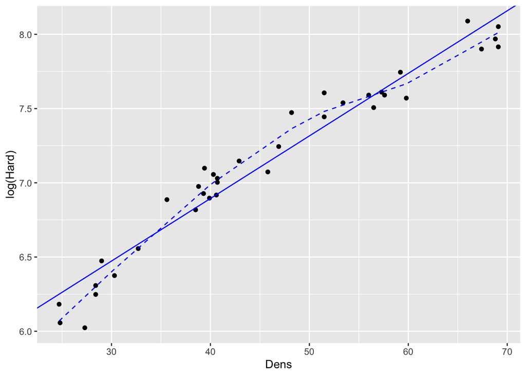

```r
#Using the ggplot and plot the data.
#This is required chart.
ggplot(df, aes(Dens, log(Hard))) + geom_point() +
  geom_line(aes(Dens, rp), color = 'blue', linetype = 'dashed') +
  geom_abline(slope = r * s_y/s_x, intercept = mu_y - r * s_y/s_x * mu_x,color = 'blue')
```